# Tarea 1: caja de herramientas de pronóstico

Series de tiempo univariadas (3009297), semestre 2026-II

Autor/a

Mariana Castaño Celis

Fecha de publicación

21 de septiembre de 2026

```r
# Se cargan las funciones propias.
for (a in c("R/00-lectura.R", "R/01-graficos.R", "R/02-metodos.R", "R/03-evaluacion.R")) source(a)
if (!exists("reportar_validacion")) stop(
  "El R/03-evaluacion.R cargado no define reportar_validacion(). ",
  "Directorio de trabajo: ", getwd(), ". ",
  "Archivo leido: ", normalizePath("R/03-evaluacion.R", mustWork = FALSE), ". ",
  "Ultima modificacion: ", format(file.mtime("R/03-evaluacion.R")))
```

# 1 Convenciones que fijan los números

1. **ACF muestral con divisor único $T$** (Definición 2.5 de las notas):
   $$r_h=\frac{\sum_{t=h+1}^{T}(Y_t-\bar Y)(Y_{t-h}-\bar Y)}{\sum_{t=1}^{T}(Y_t-\bar Y)^2}.$$
   El mismo $T$ divide numerador y denominador, de modo que $r_h$ coincide con `stats::acf()`; la verificación numérica aparece en el pie de cada correlograma.
2. **Banda del correlograma**: no es un estadístico de prueba sino el intervalo asintótico de $r_h$ bajo ruido blanco. Por el resultado de Bartlett, si la sucesión es i.i.d. con varianza finita, $r_h\stackrel{a}{\sim}N(0,1/n)$, y la banda es $\pm z_{1-\alpha/2}/\sqrt n\approx\pm 1.96/\sqrt n$, exactamente la línea `clim0 <- qnorm((1 + ci)/2)/sqrt(x$n.used)` de `plot.acf`. Cuando se grafica el correlograma de los errores, $n$ es **el número de errores**, no el número de observaciones de la serie.
3. **Inicializaciones**: $\hat Y_2=Y_1$ en la media simple y en el suavizamiento exponencial simple; $k$ períodos de calentamiento en la media móvil y $2k-1$ en la doble media móvil; $L_1=Y_1$ y $\hat T_1=0$ en Holt; las tendencias no tienen calentamiento porque son un ajuste por mínimos cuadrados sobre toda la muestra.
4. **Partición**: el tramo de validación son las últimas $h$ observaciones con $h=\min\{12,\lfloor 0.2T\rfloor\}$ y, en series estacionales, al menos un ciclo.
5. **MASE**: el escalador es el MAE de los pronósticos de un paso del ingenuo (o del ingenuo estacional) **dentro del tramo de estimación**. Un MASE menor que 1 significa que el método supera a ese referente.

# 2 Ejemplo 1. Media simple sobre `Nile`

## 2.1 Descripción y patrón

```r
nile <- leer_serie(Nile,
  fuente = "R datasets: Nile. Durbin y Koopman (2001), caudal anual del Nilo en Ashwan, 1871-1970",
  unidad = "Caudal anual (10^8 m^3)")
knitr::kable(describir_serie(nile, "Nile"), digits = 2)
```

| serie | fuente | unidad | frecuencia | inicio | fin | observaciones | media | desv_estandar | minimo | maximo |
| --- | --- | --- | --- | --- | --- | --- | --- | --- | --- | --- |
| Nile | R datasets: Nile. Durbin y Koopman (2001), caudal anual del Nilo en Ashwan, 1871-1970 | Caudal anual (10^8 m^3) | 1 | 1871-01-01 | 1970-01-01 | 100 | 919.35 | 169.23 | 456 | 1370 |

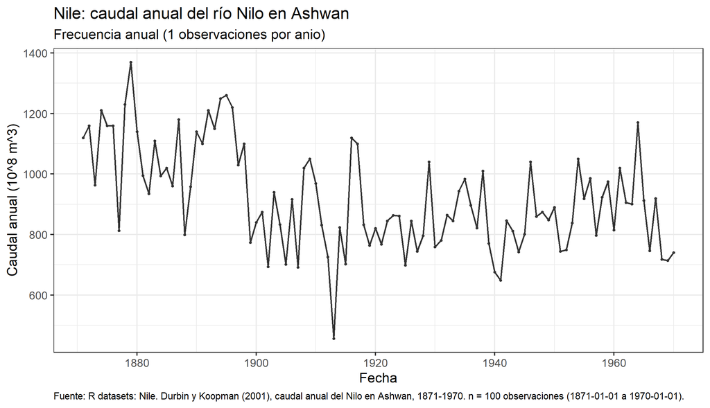

```r
graficar_serie(nile, "Nile: caudal anual del río Nilo en Ashwan")
```

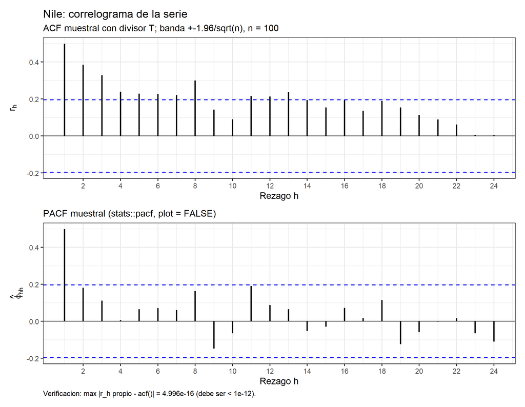

```r
correlograma(nile, titulo = "Nile: correlograma de la serie")
```

```r
rh1 <- contrastar_rh(nile$y)
knitr::kable(head(rh1, 10), digits = 4)
```

| rezago | r | banda | z | significativo | valor_p |
| --- | --- | --- | --- | --- | --- |
| 1 | 0.4984 | 0.196 | 4.9841 | TRUE | 0.0000 |
| 2 | 0.3846 | 0.196 | 3.8458 | TRUE | 0.0001 |
| 3 | 0.3279 | 0.196 | 3.2786 | TRUE | 0.0010 |
| 4 | 0.2392 | 0.196 | 2.3919 | TRUE | 0.0168 |
| 5 | 0.2284 | 0.196 | 2.2842 | TRUE | 0.0224 |
| 6 | 0.2273 | 0.196 | 2.2730 | TRUE | 0.0230 |
| 7 | 0.2220 | 0.196 | 2.2205 | TRUE | 0.0264 |
| 8 | 0.3000 | 0.196 | 2.9996 | TRUE | 0.0027 |
| 9 | 0.1417 | 0.196 | 1.4174 | FALSE | 0.1564 |
| 10 | 0.0898 | 0.196 | 0.8979 | FALSE | 0.3692 |

```r
lb1 <- ljung_box(acf_manual(nile$y)$r, T = nrow(nile), m = nrow(acf_manual(nile$y)), p = 0)
invisible(reportar_prueba(lb1,
  lectura = "La serie no es ruido blanco: hay dependencia temporal que un método de pronóstico puede aprovechar, aunque no hay tendencia sostenida."))
```

```
--- Ljung-Box ---
1. H0: rho_1 = ... = rho_m = 0 (los errores/observaciones no estan autocorrelacionados)
   H1: algun rho_h distinto de cero para h = 1,...,m
2. Estadistico: Q_m = T(T+2) sum_{h=1}^{m} r_h^2/(T-h) ~ chi^2_{m-p}  (gl = 24)
3. Region de rechazo al 5 %: se rechaza H0 si Q_m > chi^2_{0.95, 24} = 36.4150
4. Valor observado = 130.179957 ; valor p = 1.439e-16
5. Decision: se rechaza H0 al 5 %
6. Lectura: La serie no es ruido blanco: hay dependencia temporal que un método de pronóstico puede aprovechar, aunque no hay tendencia sostenida.
```

## 2.2 Ajuste, medidas y validación

```r
ej1 <- protocolo_ejemplo(nile, "Nile", ajustar_media, "media simple", p = 1, imprimir = FALSE)
knitr::kable(dplyr::bind_rows(
  dplyr::mutate(ej1$medidas_dentro,   tramo = "estimación (un paso)"),
  dplyr::mutate(ej1$medidas_fuera,    tramo = "validación (h pasos)"),
  dplyr::mutate(ej1$medidas_referente,tramo = "ingenuo (validación)")), digits = 3)
```

| n | MSE | RMSE | MAD | MAPE | MASE | tramo |
| --- | --- | --- | --- | --- | --- | --- |
| 87 | 31112.49 | 176.387 | 145.057 | 17.887 | 1.092 | estimación (un paso) |
| 12 | 19867.93 | 140.954 | 111.994 | 13.590 | 0.843 | validación (h pasos) |
| 12 | 19685.00 | 140.303 | 111.000 | 13.454 | 0.835 | ingenuo (validación) |

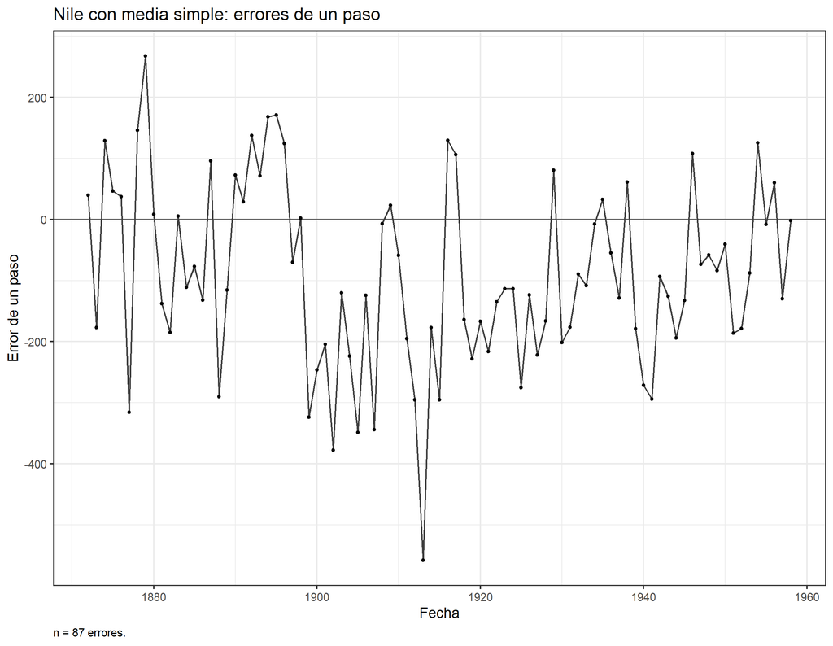

```r
ej1$validacion$grafico_errores
```

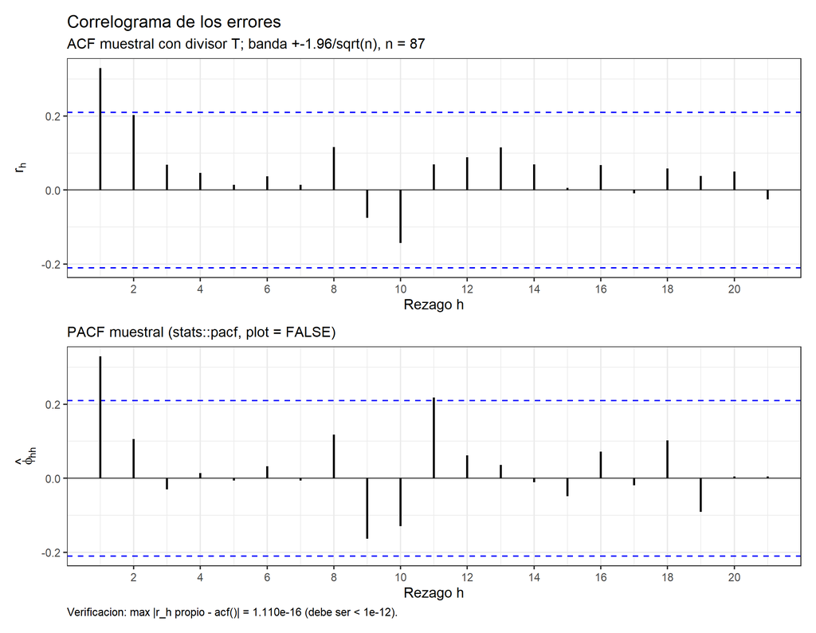

```r
ej1$validacion$correlograma
```

```r
reportar_validacion(ej1, incluir_serie = FALSE)
```

```
=== Pruebas sobre los errores de un paso: Nile con media simple ===
--- t de media cero ---
1. H0: mu_e = 0 (el metodo no esta sesgado)
   H1: mu_e != 0 (el metodo esta sesgado)
2. Estadistico: t = ebar / (s_e/sqrt(n)) ~ t_{n-1}  (gl = 86)
3. Region de rechazo al 5 %: se rechaza H0 si |t| > t_{0.975, 86} = 1.9879
4. Valor observado = -5.718179 ; valor p = 1.526e-07
5. Decision: se rechaza H0 al 5 %
6. Lectura: Se rechaza H0: hay evidencia de sesgo sistematico en los errores de un paso de Nile con media simple; el metodo tiende a sobrestimar (error medio negativo).

--- Ljung-Box ---
1. H0: rho_1 = ... = rho_m = 0 (los errores/observaciones no estan autocorrelacionados)
   H1: algun rho_h distinto de cero para h = 1,...,m
2. Estadistico: Q_m = T(T+2) sum_{h=1}^{m} r_h^2/(T-h) ~ chi^2_{m-p}  (gl = 20)
3. Region de rechazo al 5 %: se rechaza H0 si Q_m > chi^2_{0.95, 20} = 31.4104
4. Valor observado = 22.839160 ; valor p = 0.2968
5. Decision: no se rechaza H0 al 5 %
6. Lectura: No se rechaza H0: no hay evidencia de autocorrelacion en los errores de un paso de Nile con media simple.

--- Jarque-Bera ---
1. H0: los errores provienen de una distribucion normal (A = 0 y K = 3)
   H1: los errores no son normales (A != 0 o K != 3)
2. Estadistico: JB = (N/6)(A^2 + (K-3)^2/4) ~ chi^2_2  (gl = 2)
3. Region de rechazo al 5 %: se rechaza H0 si JB > chi^2_{0.95,2} = 5.9915
4. Valor observado = 0.210229 ; valor p = 0.9002
5. Decision: no se rechaza H0 al 5 %
6. Lectura: No se rechaza H0: la distribucion de los errores de un paso de Nile con media simple es compatible con la normal.

--- Durbin-Watson ---
1. H0: rho = 0 (errores no autocorrelacionados de orden 1)
   H1: rho > 0 (autocorrelacion positiva de primer orden)
2. Estadistico: d = sum_t (e_t - e_{t-1})^2 / sum_t e_t^2, con d aprox 2(1 - rho)
3. Region de rechazo al 5 %: se rechaza H0 si d < dL; no se concluye si dL <= d <= dU; no se rechaza si d > dU (cotas de la tabla para T y k regresores)
4. Valor observado = 0.962147 ; valor p = no disponible (ver cotas)
5. Decision: la decision se toma con las cotas dL y dU de la tabla (ver informe)
6. Lectura: d = 0.962, por debajo de 2: sugiere autocorrelacion positiva de primer orden en los errores de un paso de Nile con media simple; la decision formal se toma con las cotas dL y dU de la tabla.
```

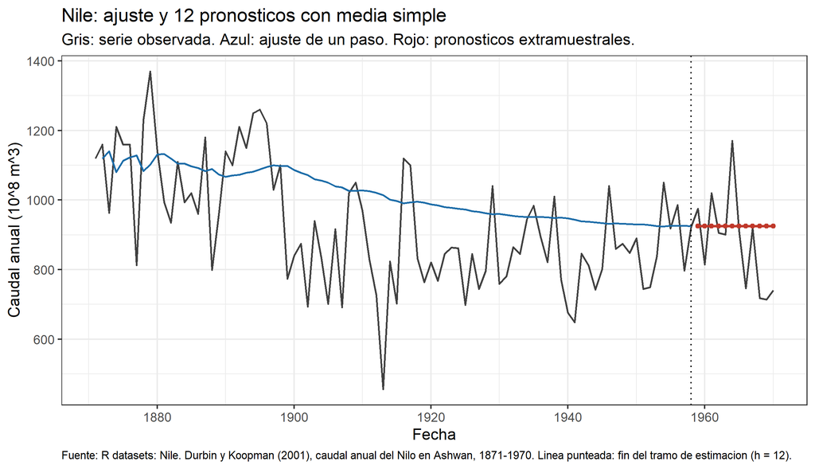

```r
ej1$grafico_final
```

## 2.3 Conclusión y recomendación

**Conclusión.** Se ajustó la media simple, sin constantes que elegir, sobre las 88 primeras observaciones. Dentro del tramo de estimación el MSE de un paso fue 3.11125^{4} y el MAD 145.1; sobre las 12 observaciones de validación el MSE fue 1.98679^{4} con MASE = 0.843, frente a MASE = 0.835 del pronóstico ingenuo sobre el mismo tramo y el mismo horizonte. La validación de errores se resume así:

```r
knitr::kable(ej1$validacion$resumen, digits = 4)
```

| prueba | estadistico | gl | critico | valor_p |
| --- | --- | --- | --- | --- |
| t de media cero | -5.7182 | 86 | 1.9879 | 0.0000 |
| Ljung-Box | 22.8392 | 20 | 31.4104 | 0.2968 |
| Jarque-Bera | 0.2102 | 2 | 5.9915 | 0.9002 |
| Durbin-Watson | 0.9621 | NA | NA | NA |

**Recomendación.** Sirve como referencia comparativa de bajo costo, no como pronóstico operativo: el método está significativamente sesgado (t = -5.72, $p<0.001$), y ni siquiera supera al ingenuo sobre este tramo (MASE 0.843 contra 0.835)

# 3 Ejemplo 2. Media móvil sobre `LakeHuron`

```r
huron <- leer_serie(LakeHuron,
  fuente = "R datasets: LakeHuron. Brockwell y Davis (1991), nivel anual del lago Huron en julio, 1875-1972",
  unidad = "Nivel del lago (pies)")
knitr::kable(describir_serie(huron, "LakeHuron"), digits = 2)
```

| serie | fuente | unidad | frecuencia | inicio | fin | observaciones | media | desv_estandar | minimo | maximo |
| --- | --- | --- | --- | --- | --- | --- | --- | --- | --- | --- |
| LakeHuron | R datasets: LakeHuron. Brockwell y Davis (1991), nivel anual del lago Huron en julio, 1875-1972 | Nivel del lago (pies) | 1 | 1875-01-01 | 1972-01-01 | 98 | 579 | 1.32 | 575.96 | 581.86 |

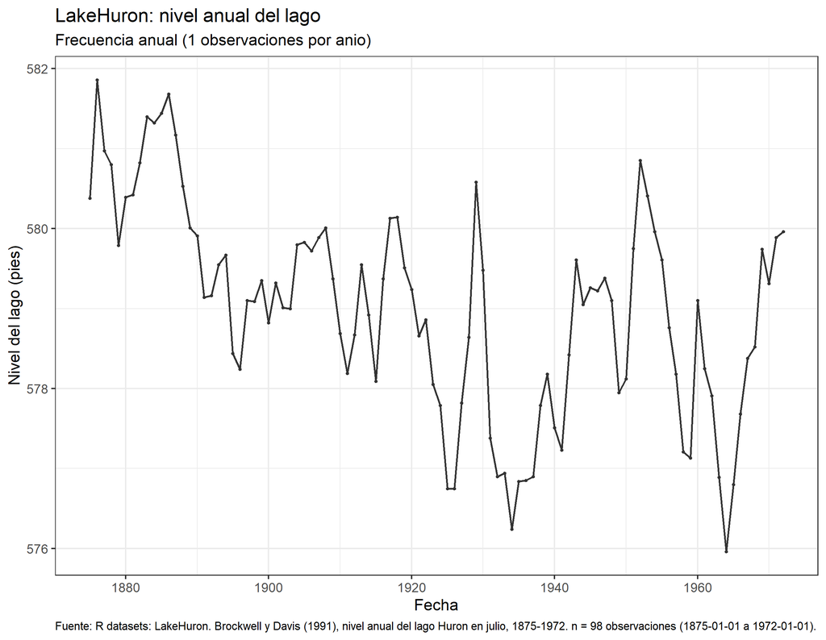

```r
graficar_serie(huron, "LakeHuron: nivel anual del lago")
```

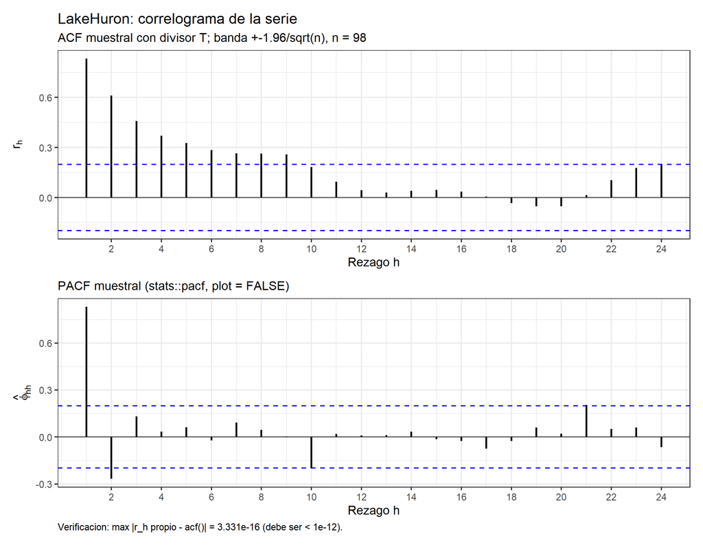

```r
correlograma(huron, titulo = "LakeHuron: correlograma de la serie")
```

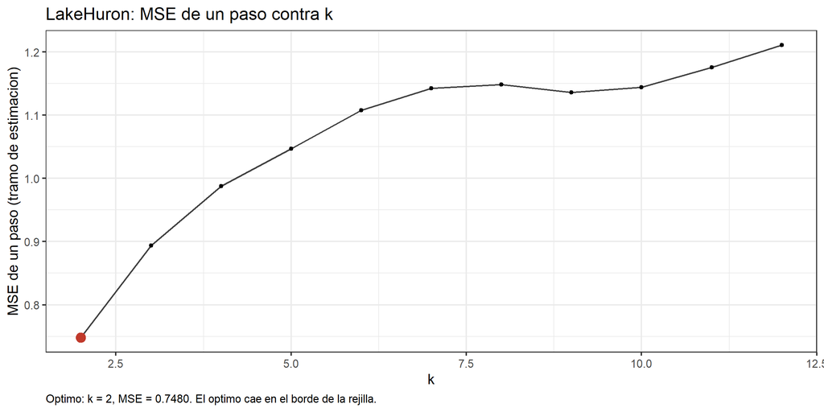

```r
p2 <- particionar(huron)
opt2 <- optimizar(p2$estimacion$y, "mm")
graficar_optimizacion(opt2, "LakeHuron: MSE de un paso contra k")
```

```r
k2 <- opt2$optimo$k
```

La ventana no se fija a ojo: sale de la rejilla $k=2,\dots,12$ evaluando el MSE de un paso dentro del tramo de estimación. El óptimo es $k=$ 2 y cae en el borde de la rejilla, lo cual indica que la ventana preferida podría estar fuera del rango evaluado.

```r
ej2 <- protocolo_ejemplo(huron, "LakeHuron", function(y) ajustar_mm(y, k2),
                         sprintf("media móvil (k = %d)", k2), p = 1, imprimir = FALSE)
knitr::kable(dplyr::bind_rows(
  dplyr::mutate(ej2$medidas_dentro,   tramo = "estimación"),
  dplyr::mutate(ej2$medidas_fuera,    tramo = "validación"),
  dplyr::mutate(ej2$medidas_referente,tramo = "ingenuo")), digits = 3)
```

| n | MSE | RMSE | MAD | MAPE | MASE | tramo |
| --- | --- | --- | --- | --- | --- | --- |
| 84 | 0.748 | 0.865 | 0.672 | 0.116 | 1.170 | estimación |
| 12 | 1.582 | 1.258 | 1.048 | 0.181 | 1.826 | validación |
| 12 | 2.238 | 1.496 | 1.243 | 0.215 | 2.164 | ingenuo |

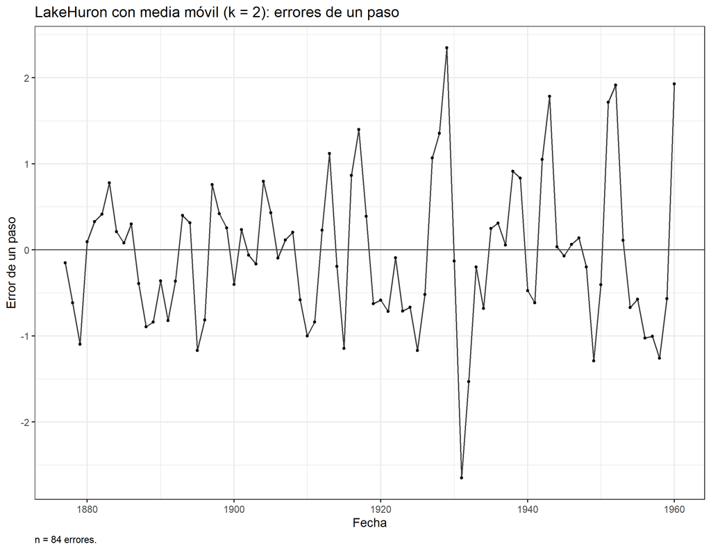

```r
ej2$validacion$grafico_errores
```

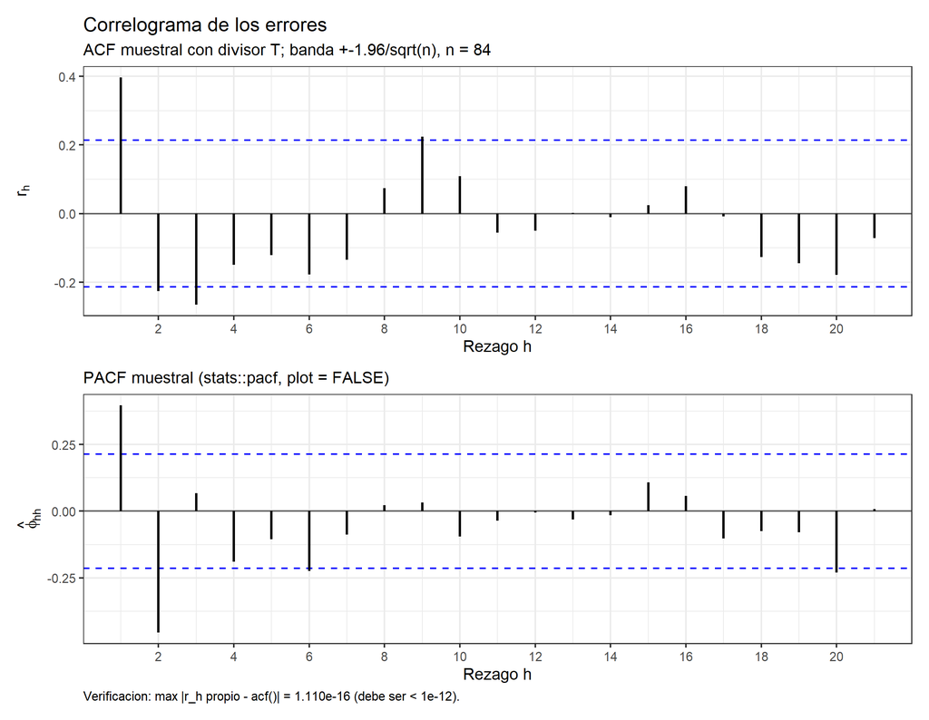

```r
ej2$validacion$correlograma
```

```r
reportar_validacion(ej2)
```

```
=== Prueba sobre la serie LakeHuron ===
--- Ljung-Box ---
1. H0: rho_1 = ... = rho_m = 0 (los errores/observaciones no estan autocorrelacionados)
   H1: algun rho_h distinto de cero para h = 1,...,m
2. Estadistico: Q_m = T(T+2) sum_{h=1}^{m} r_h^2/(T-h) ~ chi^2_{m-p}  (gl = 24)
3. Region de rechazo al 5 %: se rechaza H0 si Q_m > chi^2_{0.95, 24} = 36.4150
4. Valor observado = 203.236844 ; valor p = 2.468e-30
5. Decision: se rechaza H0 al 5 %
6. Lectura: Se rechaza H0: hay autocorrelacion (estructura temporal) en la serie LakeHuron.

=== Pruebas sobre los errores de un paso: LakeHuron con media móvil (k = 2) ===
--- t de media cero ---
1. H0: mu_e = 0 (el metodo no esta sesgado)
   H1: mu_e != 0 (el metodo esta sesgado)
2. Estadistico: t = ebar / (s_e/sqrt(n)) ~ t_{n-1}  (gl = 83)
3. Region de rechazo al 5 %: se rechaza H0 si |t| > t_{0.975, 83} = 1.9890
4. Valor observado = -0.550901 ; valor p = 0.5832
5. Decision: no se rechaza H0 al 5 %
6. Lectura: No se rechaza H0: no hay evidencia de sesgo sistematico en los errores de un paso de LakeHuron con media móvil (k = 2).

--- Ljung-Box ---
1. H0: rho_1 = ... = rho_m = 0 (los errores/observaciones no estan autocorrelacionados)
   H1: algun rho_h distinto de cero para h = 1,...,m
2. Estadistico: Q_m = T(T+2) sum_{h=1}^{m} r_h^2/(T-h) ~ chi^2_{m-p}  (gl = 20)
3. Region de rechazo al 5 %: se rechaza H0 si Q_m > chi^2_{0.95, 20} = 31.4104
4. Valor observado = 48.450700 ; valor p = 0.0003676
5. Decision: se rechaza H0 al 5 %
6. Lectura: Se rechaza H0: hay autocorrelacion (estructura temporal) en los errores de un paso de LakeHuron con media móvil (k = 2).

--- Jarque-Bera ---
1. H0: los errores provienen de una distribucion normal (A = 0 y K = 3)
   H1: los errores no son normales (A != 0 o K != 3)
2. Estadistico: JB = (N/6)(A^2 + (K-3)^2/4) ~ chi^2_2  (gl = 2)
3. Region de rechazo al 5 %: se rechaza H0 si JB > chi^2_{0.95,2} = 5.9915
4. Valor observado = 2.990382 ; valor p = 0.2242
5. Decision: no se rechaza H0 al 5 %
6. Lectura: No se rechaza H0: la distribucion de los errores de un paso de LakeHuron con media móvil (k = 2) es compatible con la normal.

--- Durbin-Watson ---
1. H0: rho = 0 (errores no autocorrelacionados de orden 1)
   H1: rho > 0 (autocorrelacion positiva de primer orden)
2. Estadistico: d = sum_t (e_t - e_{t-1})^2 / sum_t e_t^2, con d aprox 2(1 - rho)
3. Region de rechazo al 5 %: se rechaza H0 si d < dL; no se concluye si dL <= d <= dU; no se rechaza si d > dU (cotas de la tabla para T y k regresores)
4. Valor observado = 1.139188 ; valor p = no disponible (ver cotas)
5. Decision: la decision se toma con las cotas dL y dU de la tabla (ver informe)
6. Lectura: d = 1.139, por debajo de 2: sugiere autocorrelacion positiva de primer orden en los errores de un paso de LakeHuron con media móvil (k = 2); la decision formal se toma con las cotas dL y dU de la tabla.
```

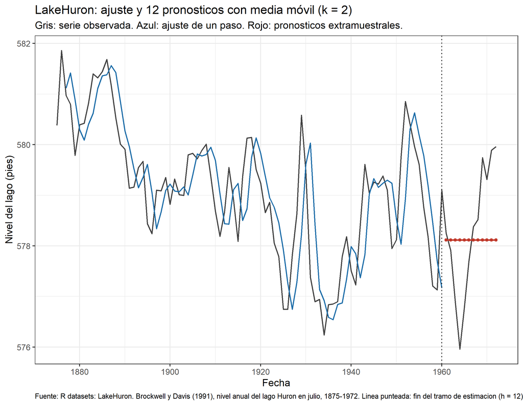

```r
ej2$grafico_final
```

**Conclusión.** Media móvil con $k=$ 2, calentamiento de 2 períodos; MSE de validación 1.5817 y MASE 1.826 contra 2.164 del ingenuo.

**Recomendación.** Sirve para una gestión hidrológica de corto plazo del nivel del lago (uno o dos años), donde el objetivo es seguir el nivel reciente más que proyectar una tendencia. El límite es justo lo que muestra Ljung–Box: el método no agota toda la dependencia temporal disponible, así que antes de usarlo de forma operativa vale la pena comparar contra el suavizamiento exponencial simple

# 4 Ejemplo 3. Suavizamiento exponencial simple sobre `Nile`

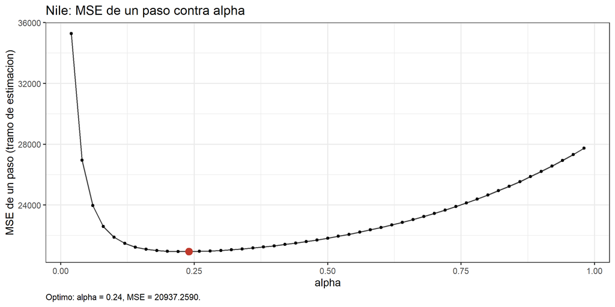

```r
p3 <- particionar(nile)
opt3 <- optimizar(p3$estimacion$y, "ses")
graficar_optimizacion(opt3, "Nile: MSE de un paso contra alpha")
```

```r
a3 <- opt3$optimo$alpha
```

El óptimo alpha = 0.24 cae en el interior de la rejilla: la serie tiene memoria, el nivel se actualiza de forma gradual.

```r
ej3 <- protocolo_ejemplo(nile, "Nile", function(y) ajustar_ses(y, a3),
                         sprintf("SES (alpha = %.2f)", a3), p = 1, imprimir = FALSE)
knitr::kable(dplyr::bind_rows(
  dplyr::mutate(ej3$medidas_dentro,   tramo = "estimación"),
  dplyr::mutate(ej3$medidas_fuera,    tramo = "validación"),
  dplyr::mutate(ej3$medidas_referente,tramo = "ingenuo")), digits = 3)
```

| n | MSE | RMSE | MAD | MAPE | MASE | tramo |
| --- | --- | --- | --- | --- | --- | --- |
| 87 | 20937.26 | 144.697 | 113.606 | 13.089 | 0.855 | estimación |
| 12 | 17864.46 | 133.658 | 107.117 | 12.600 | 0.806 | validación |
| 12 | 19685.00 | 140.303 | 111.000 | 13.454 | 0.835 | ingenuo |

```r
# Verificación: corrección de error vs promedio ponderado (diferencia máxima)
ej3$ajuste$parametros$dif_max_formas
```

```
[1] 2.273737e-13
```

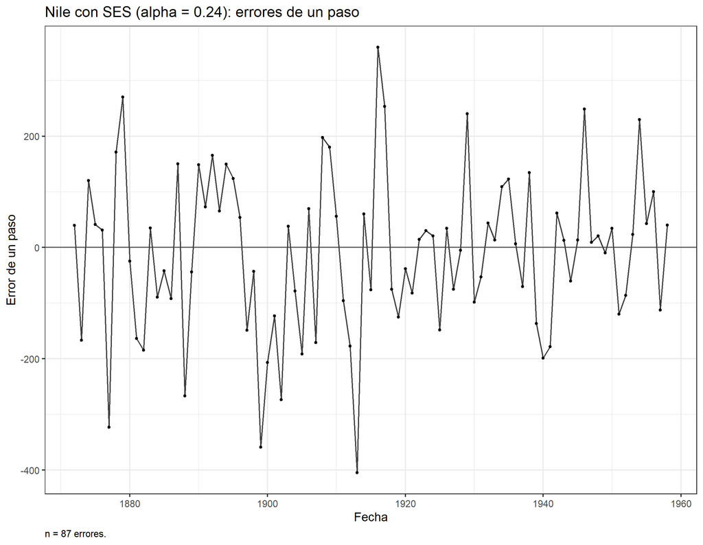

```r
ej3$validacion$grafico_errores
```

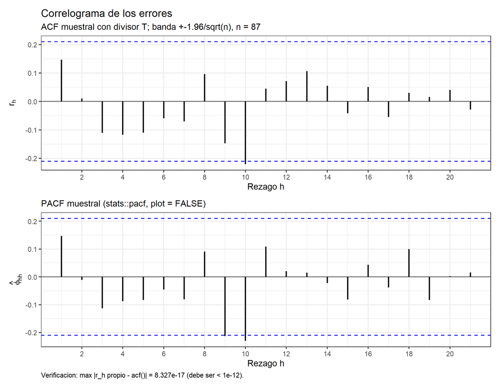

```r
ej3$validacion$correlograma
```

```r
reportar_validacion(ej3)
```

```
=== Prueba sobre la serie Nile ===
--- Ljung-Box ---
1. H0: rho_1 = ... = rho_m = 0 (los errores/observaciones no estan autocorrelacionados)
   H1: algun rho_h distinto de cero para h = 1,...,m
2. Estadistico: Q_m = T(T+2) sum_{h=1}^{m} r_h^2/(T-h) ~ chi^2_{m-p}  (gl = 24)
3. Region de rechazo al 5 %: se rechaza H0 si Q_m > chi^2_{0.95, 24} = 36.4150
4. Valor observado = 130.179957 ; valor p = 1.439e-16
5. Decision: se rechaza H0 al 5 %
6. Lectura: Se rechaza H0: hay autocorrelacion (estructura temporal) en la serie Nile.

=== Pruebas sobre los errores de un paso: Nile con SES (alpha = 0.24) ===
--- t de media cero ---
1. H0: mu_e = 0 (el metodo no esta sesgado)
   H1: mu_e != 0 (el metodo esta sesgado)
2. Estadistico: t = ebar / (s_e/sqrt(n)) ~ t_{n-1}  (gl = 86)
3. Region de rechazo al 5 %: se rechaza H0 si |t| > t_{0.975, 86} = 1.9879
4. Valor observado = -0.700908 ; valor p = 0.4853
5. Decision: no se rechaza H0 al 5 %
6. Lectura: No se rechaza H0: no hay evidencia de sesgo sistematico en los errores de un paso de Nile con SES (alpha = 0.24).

--- Ljung-Box ---
1. H0: rho_1 = ... = rho_m = 0 (los errores/observaciones no estan autocorrelacionados)
   H1: algun rho_h distinto de cero para h = 1,...,m
2. Estadistico: Q_m = T(T+2) sum_{h=1}^{m} r_h^2/(T-h) ~ chi^2_{m-p}  (gl = 20)
3. Region de rechazo al 5 %: se rechaza H0 si Q_m > chi^2_{0.95, 20} = 31.4104
4. Valor observado = 17.757166 ; valor p = 0.6034
5. Decision: no se rechaza H0 al 5 %
6. Lectura: No se rechaza H0: no hay evidencia de autocorrelacion en los errores de un paso de Nile con SES (alpha = 0.24).

--- Jarque-Bera ---
1. H0: los errores provienen de una distribucion normal (A = 0 y K = 3)
   H1: los errores no son normales (A != 0 o K != 3)
2. Estadistico: JB = (N/6)(A^2 + (K-3)^2/4) ~ chi^2_2  (gl = 2)
3. Region de rechazo al 5 %: se rechaza H0 si JB > chi^2_{0.95,2} = 5.9915
4. Valor observado = 0.330437 ; valor p = 0.8477
5. Decision: no se rechaza H0 al 5 %
6. Lectura: No se rechaza H0: la distribucion de los errores de un paso de Nile con SES (alpha = 0.24) es compatible con la normal.

--- Durbin-Watson ---
1. H0: rho = 0 (errores no autocorrelacionados de orden 1)
   H1: rho > 0 (autocorrelacion positiva de primer orden)
2. Estadistico: d = sum_t (e_t - e_{t-1})^2 / sum_t e_t^2, con d aprox 2(1 - rho)
3. Region de rechazo al 5 %: se rechaza H0 si d < dL; no se concluye si dL <= d <= dU; no se rechaza si d > dU (cotas de la tabla para T y k regresores)
4. Valor observado = 1.693526 ; valor p = no disponible (ver cotas)
5. Decision: la decision se toma con las cotas dL y dU de la tabla (ver informe)
6. Lectura: d = 1.694, cercano a 2: no sugiere autocorrelacion relevante de primer orden en los errores de un paso de Nile con SES (alpha = 0.24); la decision formal se toma con las cotas dL y dU de la tabla.
```

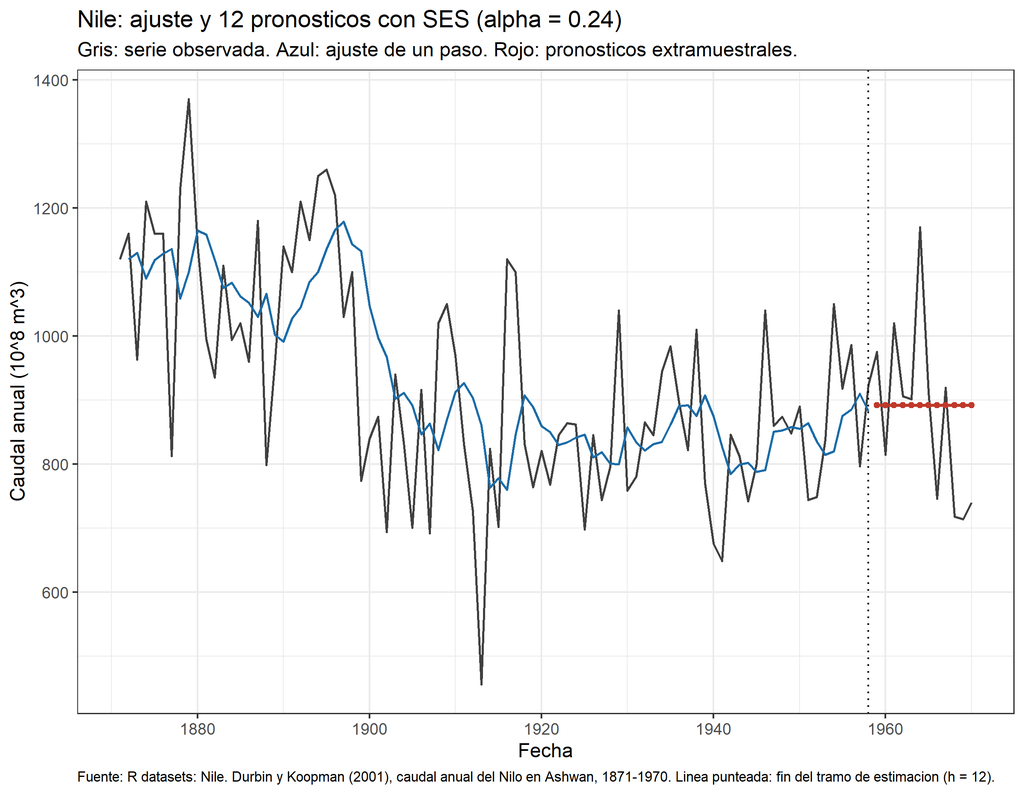

```r
ej3$grafico_final
```

**Conclusión.** El suavizamiento exponencial simple, con $\alpha=$ 0.24 elegido por rejilla (óptimo en el interior, no en el borde), mejora sobre la media simple del Ejemplo 1 en las cuatro medidas: MSE de validación 1.7864^{4} frente a 1.9868^{4}, y MASE 0.806 frente a 0.843. También supera al ingenuo (0.806 contra 0.835). La forma de corrección de error coincide con el promedio ponderado con una diferencia máxima de 2.27e-13. De las cuatro pruebas de validación, ninguna rechaza $H_0$: sin sesgo ($p=$ 0.485), sin autocorrelación residual (Ljung–Box $p=$ 0.603) y errores normales (Jarque–Bera $p=$ 0.848): es el método mejor comportado de los cuatro ejemplos de nivel.

**Recomendación.** Es el método preferido para pronóstico operativo de corto plazo del caudal del Nilo, con validación limpia hasta el horizonte evaluado (12 años). El límite es estructural, no estadístico: al ser un método de nivel sin tendencia, si el caudal vuelve a sufrir un cambio de régimen (como ocurrió hacia 1899), el pronóstico solo se adapta gradualmente, a un ritmo que depende de $\alpha=$ 0.24 — cuanto más bajo, más lento.

# 5 Ejemplo 4. Doble media móvil sobre `austres`

```r
austres_d <- leer_serie(austres,
  fuente = "R datasets: austres. Brockwell y Davis (1996), residentes en Australia, trimestral 1971:2-1993:3",
  unidad = "Residentes (miles de personas)")
knitr::kable(describir_serie(austres_d, "austres"), digits = 2)
```

| serie | fuente | unidad | frecuencia | inicio | fin | observaciones | media | desv_estandar | minimo | maximo |
| --- | --- | --- | --- | --- | --- | --- | --- | --- | --- | --- |
| austres | R datasets: austres. Brockwell y Davis (1996), residentes en Australia, trimestral 1971:2-1993:3 | Residentes (miles de personas) | 4 | 1971-04-01 | 1993-04-01 | 89 | 15273.45 | 1356.81 | 13067.3 | 17661.5 |

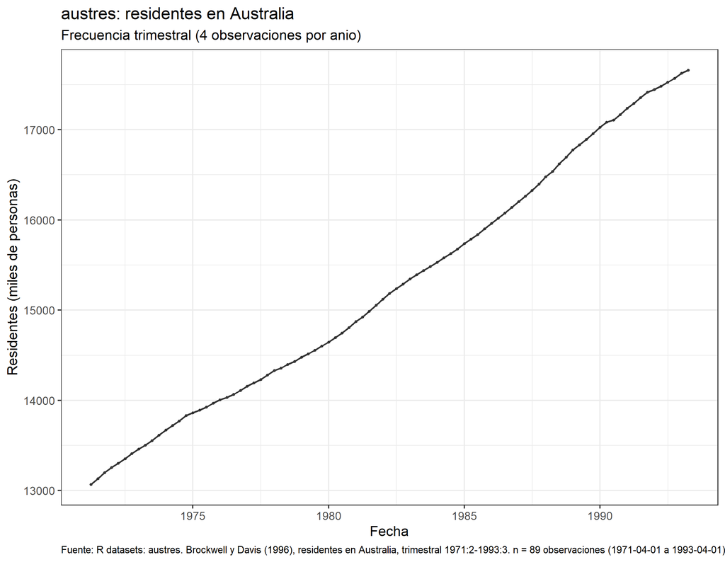

```r
graficar_serie(austres_d, "austres: residentes en Australia")
```

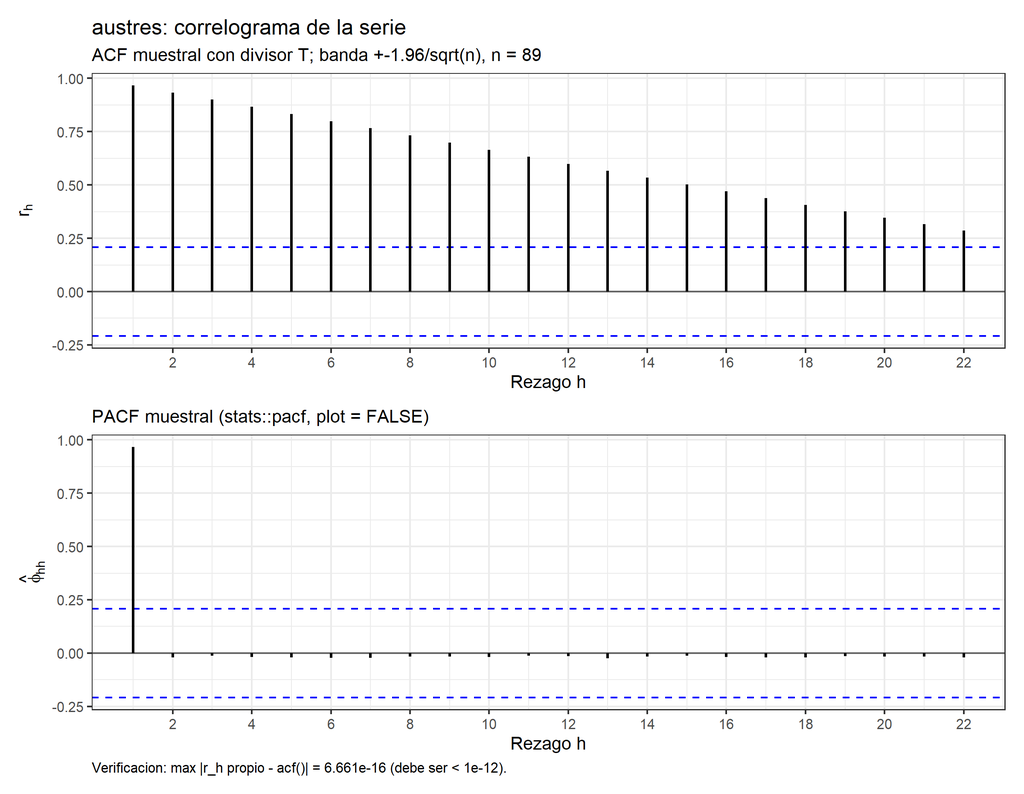

```r
correlograma(austres_d, titulo = "austres: correlograma de la serie")
```

La ACF decae linealmente y muy despacio, la marca de una tendencia sostenida; no hay picos en los múltiplos de 4, es decir, no hay estacionalidad trimestral apreciable. Por eso el referente es el ingenuo simple y no el estacional.

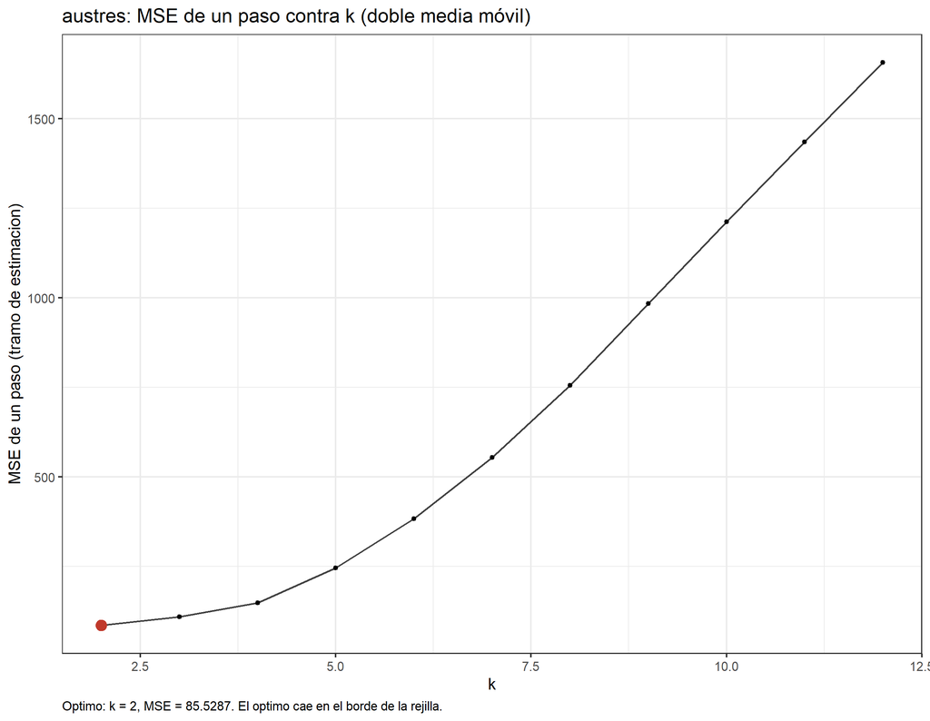

```r
p4 <- particionar(austres_d)
opt4 <- optimizar(p4$estimacion$y, "dmm")
graficar_optimizacion(opt4, "austres: MSE de un paso contra k (doble media móvil)")
```

```r
k4 <- opt4$optimo$k
ej4 <- protocolo_ejemplo(austres_d, "austres", function(y) ajustar_dmm(y, k4),
                         sprintf("doble media móvil (k = %d)", k4), p = 2, imprimir = FALSE)
knitr::kable(dplyr::bind_rows(
  dplyr::mutate(ej4$medidas_dentro,   tramo = "estimación"),
  dplyr::mutate(ej4$medidas_fuera,    tramo = "validación"),
  dplyr::mutate(ej4$medidas_referente,tramo = "ingenuo")), digits = 3)
```

| n | MSE | RMSE | MAD | MAPE | MASE | tramo |
| --- | --- | --- | --- | --- | --- | --- |
| 74 | 85.529 | 9.248 | 7.498 | 0.050 | 0.142 | estimación |
| 12 | 12643.421 | 112.443 | 98.508 | 0.563 | 1.863 | validación |
| 12 | 133004.791 | 364.698 | 322.042 | 1.841 | 6.091 | ingenuo |

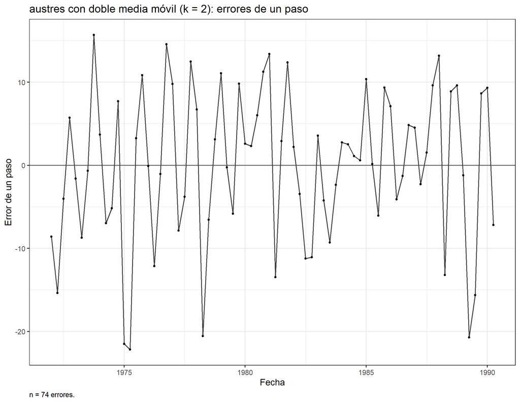

```r
ej4$validacion$grafico_errores
```

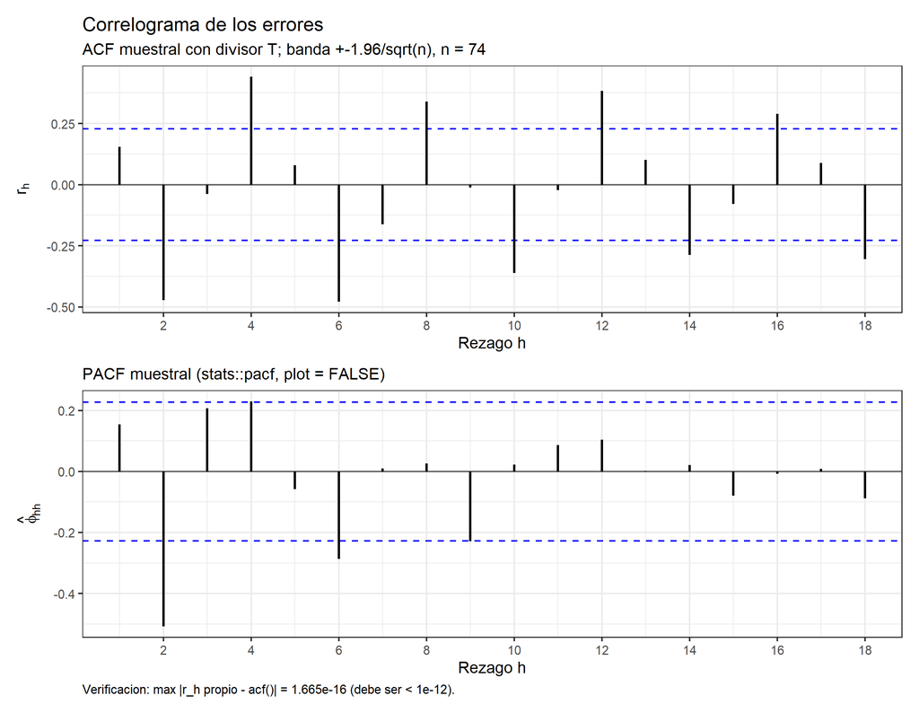

```r
ej4$validacion$correlograma
```

```r
reportar_validacion(ej4)
```

```
=== Prueba sobre la serie austres ===
--- Ljung-Box ---
1. H0: rho_1 = ... = rho_m = 0 (los errores/observaciones no estan autocorrelacionados)
   H1: algun rho_h distinto de cero para h = 1,...,m
2. Estadistico: Q_m = T(T+2) sum_{h=1}^{m} r_h^2/(T-h) ~ chi^2_{m-p}  (gl = 22)
3. Region de rechazo al 5 %: se rechaza H0 si Q_m > chi^2_{0.95, 22} = 33.9244
4. Valor observado = 938.952221 ; valor p = 1.883e-184
5. Decision: se rechaza H0 al 5 %
6. Lectura: Se rechaza H0: hay autocorrelacion (estructura temporal) en la serie austres.

=== Pruebas sobre los errores de un paso: austres con doble media móvil (k = 2) ===
--- t de media cero ---
1. H0: mu_e = 0 (el metodo no esta sesgado)
   H1: mu_e != 0 (el metodo esta sesgado)
2. Estadistico: t = ebar / (s_e/sqrt(n)) ~ t_{n-1}  (gl = 73)
3. Region de rechazo al 5 %: se rechaza H0 si |t| > t_{0.975, 73} = 1.9930
4. Valor observado = -0.050876 ; valor p = 0.9596
5. Decision: no se rechaza H0 al 5 %
6. Lectura: No se rechaza H0: no hay evidencia de sesgo sistematico en los errores de un paso de austres con doble media móvil (k = 2).

--- Ljung-Box ---
1. H0: rho_1 = ... = rho_m = 0 (los errores/observaciones no estan autocorrelacionados)
   H1: algun rho_h distinto de cero para h = 1,...,m
2. Estadistico: Q_m = T(T+2) sum_{h=1}^{m} r_h^2/(T-h) ~ chi^2_{m-p}  (gl = 16)
3. Region de rechazo al 5 %: se rechaza H0 si Q_m > chi^2_{0.95, 16} = 26.2962
4. Valor observado = 118.836816 ; valor p = 9.19e-18
5. Decision: se rechaza H0 al 5 %
6. Lectura: Se rechaza H0: hay autocorrelacion (estructura temporal) en los errores de un paso de austres con doble media móvil (k = 2).

--- Jarque-Bera ---
1. H0: los errores provienen de una distribucion normal (A = 0 y K = 3)
   H1: los errores no son normales (A != 0 o K != 3)
2. Estadistico: JB = (N/6)(A^2 + (K-3)^2/4) ~ chi^2_2  (gl = 2)
3. Region de rechazo al 5 %: se rechaza H0 si JB > chi^2_{0.95,2} = 5.9915
4. Valor observado = 3.493720 ; valor p = 0.1743
5. Decision: no se rechaza H0 al 5 %
6. Lectura: No se rechaza H0: la distribucion de los errores de un paso de austres con doble media móvil (k = 2) es compatible con la normal.

--- Durbin-Watson ---
1. H0: rho = 0 (errores no autocorrelacionados de orden 1)
   H1: rho > 0 (autocorrelacion positiva de primer orden)
2. Estadistico: d = sum_t (e_t - e_{t-1})^2 / sum_t e_t^2, con d aprox 2(1 - rho)
3. Region de rechazo al 5 %: se rechaza H0 si d < dL; no se concluye si dL <= d <= dU; no se rechaza si d > dU (cotas de la tabla para T y k regresores)
4. Valor observado = 1.672003 ; valor p = no disponible (ver cotas)
5. Decision: la decision se toma con las cotas dL y dU de la tabla (ver informe)
6. Lectura: d = 1.672, cercano a 2: no sugiere autocorrelacion relevante de primer orden en los errores de un paso de austres con doble media móvil (k = 2); la decision formal se toma con las cotas dL y dU de la tabla.
```

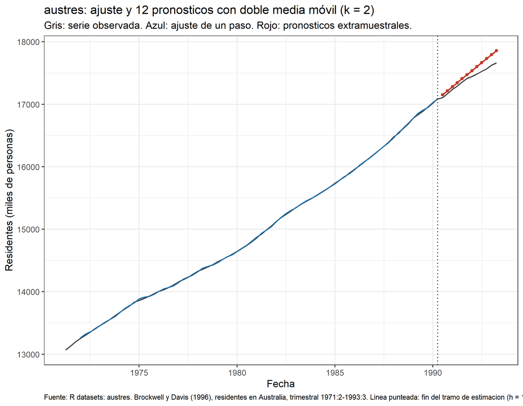

```r
ej4$grafico_final
```

**Conclusión.** La doble media móvil, con $k=$ 2 (borde inferior de la rejilla 2 a 12), reduce el error de validación de forma sustancial frente al ingenuo: MASE 1.863 contra 6.091, una mejora de 69.4%. No hay sesgo en los errores ($t=$ -0.051, $p=$ 0.96) y son normales (Jarque–Bera $p=$ 0.174), pero Ljung–Box rechaza con altísima confianza (Q = 118.8, $p=$ 9.19e-18): queda estructura temporal considerable sin capturar, señal de que el crecimiento de `austres` no es perfectamente lineal-local dentro de cada ventana de 2 trimestres.

**Recomendación.** Útil para proyectar el número de residentes en Australia a un plazo corto (unos pocos trimestres), donde la ganancia frente al ingenuo es grande y clara. El límite es el fuerte rechazo de Ljung–Box: antes de usarlo para decisiones de política pública a mediano plazo conviene contrastarlo contra una tendencia global (Ejemplo 5) para verificar si la curvatura o los ciclos que el correlograma de errores sugiere son sistemáticos.

# 6 Ejemplo 5. Tendencia lineal sobre `austres`

```r
ej5 <- protocolo_ejemplo(austres_d, "austres", function(y) ajustar_tendencia(y, "lineal"),
                         "tendencia lineal", p = 2, imprimir = FALSE)
par5 <- ej5$ajuste$parametros
knitr::kable(par5$tabla_coeficientes, digits = 5)
```

| coeficiente | estimacion | ee_ordinario | t_ordinario | p_ordinario | ee_hac | t_hac | p_hac |
| --- | --- | --- | --- | --- | --- | --- | --- |
| b0 | 12963.28824 | 21.95795 | 590.3688 | 0 | 40.73278 | 318.25200 | 0 |
| b1 | 50.70746 | 0.48916 | 103.6615 | 0 | 1.04905 | 48.33646 | 0 |

```r
c(R2 = par5$R2, sigma2 = par5$sigma2, DW = par5$durbin_watson,
  rezagos_HAC = par5$rezagos_hac, gl = par5$gl)
```

```
          R2       sigma2           DW  rezagos_HAC           gl
9.930688e-01 9.101777e+03 1.705571e-02 3.000000e+00 7.500000e+01
```

```r
for (j in seq_len(nrow(par5$tabla_coeficientes))) {
  tc <- par5$tabla_coeficientes[j, ]
  invisible(reportar_prueba(t_coeficiente(tc$estimacion, tc$ee_hac, par5$gl, tc$coeficiente)))
}
```

```
--- t sobre b0 (EE robusto HAC) ---
1. H0: b0 = 0
   H1: b0 != 0
2. Estadistico: t = b0_hat / EE_HAC(b0_hat) ~ t_{T-k}  (gl = 75)
3. Region de rechazo al 5 %: se rechaza H0 si |t| > t_{0.975, 75} = 1.9921
4. Valor observado = 318.252003 ; valor p = 3.614e-119
5. Decision: se rechaza H0 al 5 %
6. Lectura: Se rechaza H0: el coeficiente b0 es significativamente distinto de cero (con error estandar robusto HAC).

--- t sobre b1 (EE robusto HAC) ---
1. H0: b1 = 0
   H1: b1 != 0
2. Estadistico: t = b1_hat / EE_HAC(b1_hat) ~ t_{T-k}  (gl = 75)
3. Region de rechazo al 5 %: se rechaza H0 si |t| > t_{0.975, 75} = 1.9921
4. Valor observado = 48.336457 ; valor p = 2.814e-58
5. Decision: se rechaza H0 al 5 %
6. Lectura: Se rechaza H0: el coeficiente b1 es significativamente distinto de cero (con error estandar robusto HAC).
```

```r
# Bloque de verificación permitido: coeficientes propios contra lm()
tt <- seq_along(ej5$particion$estimacion$y)
max(abs(coef(lm(ej5$particion$estimacion$y ~ tt)) - par5$coeficientes))
```

```
[1] 1.63709e-11
```

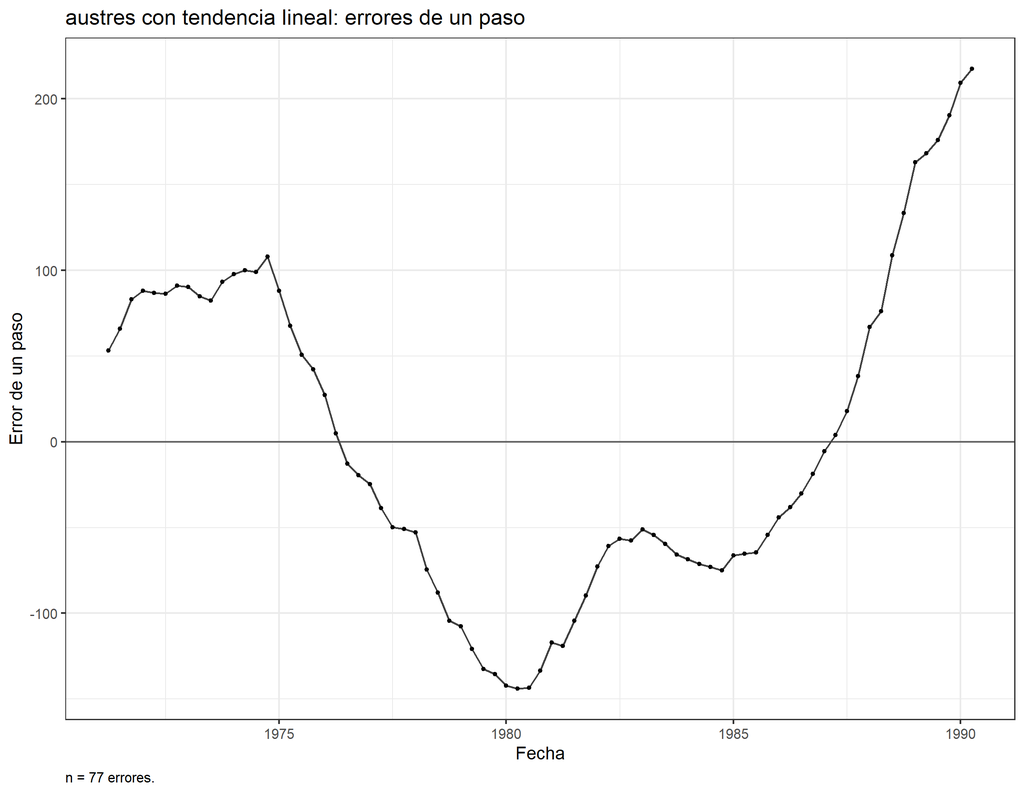

```r
ej5$validacion$grafico_errores
```

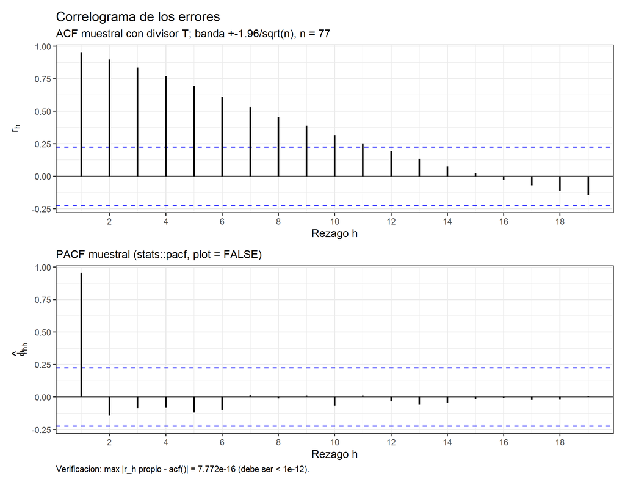

```r
ej5$validacion$correlograma
```

```r
reportar_validacion(ej5)
```

```
=== Prueba sobre la serie austres ===
--- Ljung-Box ---
1. H0: rho_1 = ... = rho_m = 0 (los errores/observaciones no estan autocorrelacionados)
   H1: algun rho_h distinto de cero para h = 1,...,m
2. Estadistico: Q_m = T(T+2) sum_{h=1}^{m} r_h^2/(T-h) ~ chi^2_{m-p}  (gl = 22)
3. Region de rechazo al 5 %: se rechaza H0 si Q_m > chi^2_{0.95, 22} = 33.9244
4. Valor observado = 938.952221 ; valor p = 1.883e-184
5. Decision: se rechaza H0 al 5 %
6. Lectura: Se rechaza H0: hay autocorrelacion (estructura temporal) en la serie austres.

=== Pruebas sobre los errores de un paso: austres con tendencia lineal ===
--- t de media cero ---
1. H0: mu_e = 0 (el metodo no esta sesgado)
   H1: mu_e != 0 (el metodo esta sesgado)
2. Estadistico: t = ebar / (s_e/sqrt(n)) ~ t_{n-1}  (gl = 76)
3. Region de rechazo al 5 %: se rechaza H0 si |t| > t_{0.975, 76} = 1.9917
4. Valor observado = -0.000000 ; valor p =     1
5. Decision: no se rechaza H0 al 5 %
6. Lectura: No se rechaza H0: no hay evidencia de sesgo sistematico en los errores de un paso de austres con tendencia lineal.

--- Ljung-Box ---
1. H0: rho_1 = ... = rho_m = 0 (los errores/observaciones no estan autocorrelacionados)
   H1: algun rho_h distinto de cero para h = 1,...,m
2. Estadistico: Q_m = T(T+2) sum_{h=1}^{m} r_h^2/(T-h) ~ chi^2_{m-p}  (gl = 17)
3. Region de rechazo al 5 %: se rechaza H0 si Q_m > chi^2_{0.95, 17} = 27.5871
4. Valor observado = 399.467559 ; valor p = 2.396e-74
5. Decision: se rechaza H0 al 5 %
6. Lectura: Se rechaza H0: hay autocorrelacion (estructura temporal) en los errores de un paso de austres con tendencia lineal.

--- Jarque-Bera ---
1. H0: los errores provienen de una distribucion normal (A = 0 y K = 3)
   H1: los errores no son normales (A != 0 o K != 3)
2. Estadistico: JB = (N/6)(A^2 + (K-3)^2/4) ~ chi^2_2  (gl = 2)
3. Region de rechazo al 5 %: se rechaza H0 si JB > chi^2_{0.95,2} = 5.9915
4. Valor observado = 4.235511 ; valor p = 0.1203
5. Decision: no se rechaza H0 al 5 %
6. Lectura: No se rechaza H0: la distribucion de los errores de un paso de austres con tendencia lineal es compatible con la normal.

--- Durbin-Watson ---
1. H0: rho = 0 (errores no autocorrelacionados de orden 1)
   H1: rho > 0 (autocorrelacion positiva de primer orden)
2. Estadistico: d = sum_t (e_t - e_{t-1})^2 / sum_t e_t^2, con d aprox 2(1 - rho)
3. Region de rechazo al 5 %: se rechaza H0 si d < dL; no se concluye si dL <= d <= dU; no se rechaza si d > dU (cotas de la tabla para T y k regresores)
4. Valor observado = 0.017056 ; valor p = no disponible (ver cotas)
5. Decision: la decision se toma con las cotas dL y dU de la tabla (ver informe)
6. Lectura: d = 0.017, por debajo de 2: sugiere autocorrelacion positiva de primer orden en los errores de un paso de austres con tendencia lineal; la decision formal se toma con las cotas dL y dU de la tabla.
```

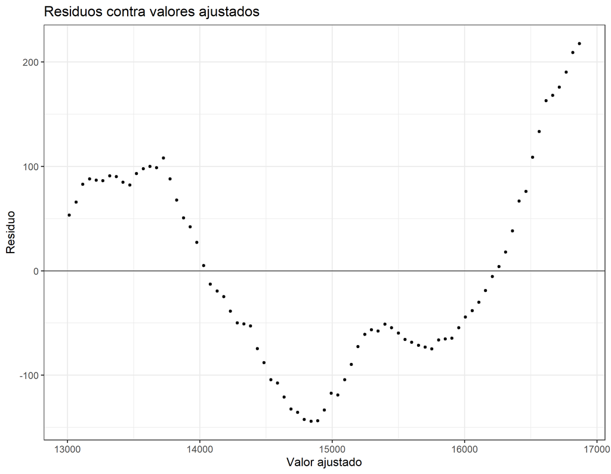

```r
library(ggplot2)
ggplot(tibble::tibble(ajustado = ej5$ajuste$yhat, residuo = ej5$errores),
       aes(ajustado, residuo)) + geom_hline(yintercept = 0, colour = "grey40") +
  geom_point(size = 1) + labs(title = "Residuos contra valores ajustados",
  x = "Valor ajustado", y = "Residuo") + theme_bw()
```

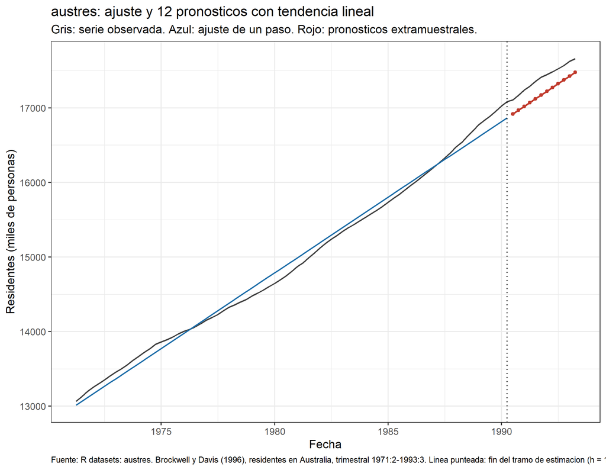

```r
ej5$grafico_final
```

Los residuos de una tendencia determinística sobre una serie con tendencia estocástica están fuertemente autocorrelacionados; con $d=0.0171$, muy por debajo de 2, la autocorrelación es positiva. En ese caso los errores estándar ordinarios subestiman la variabilidad de $\hat\beta$ y los valores $p$ ordinarios no son interpretables: la decisión sobre $H_0:\beta_j=0$ se toma con el error estándar robusto HAC de Bartlett con 3 rezagos, que es el reportado arriba.

**Conclusión.** La tendencia lineal ajustada por MCO tiene $R^2=$ 0.9931, un ajuste dentro de muestra casi perfecto, pero fuera de muestra el MASE es 3.974, peor que la doble media móvil del Ejemplo 4 (1.863) aunque todavía mejor que el ingenuo (6.091). Ambos coeficientes son significativos con el error estándar robusto HAC ($t=$ 318.3 y 48.3), pero esa significancia solo confirma que existe tendencia, no que el modelo pronostique bien. Los residuos están masivamente autocorrelacionados: $DW=$ 0.0171, casi cero, y Ljung–Box rechaza con $p=$ 2.40e-74: la tendencia global no sigue las fluctuaciones locales de la serie.

**Recomendación.** Sirve para caracterizar la tasa de crecimiento promedio de largo plazo (50.7 miles de personas por trimestre), útil para planeación demográfica a muy largo plazo, pero no para pronóstico operativo de corto o mediano plazo, donde la doble media móvil del Ejemplo 4 es claramente superior. El límite declarado es la autocorrelación residual extrema ($DW\approx0$): el supuesto de tendencia determinística constante no se sostiene en el periodo evaluado.

# 7 Ejemplo 6. Tendencia cuadrática sobre `airmiles`

```r
airm <- leer_serie(airmiles,
  fuente = "R datasets: airmiles. Brown (1963), millas-pasajero de aerolíneas comerciales de EE. UU., 1937-1960",
  unidad = "Millas-pasajero (miles)")
knitr::kable(describir_serie(airm, "airmiles"), digits = 2)
```

| serie | fuente | unidad | frecuencia | inicio | fin | observaciones | media | desv_estandar | minimo | maximo |
| --- | --- | --- | --- | --- | --- | --- | --- | --- | --- | --- |
| airmiles | R datasets: airmiles. Brown (1963), millas-pasajero de aerolíneas comerciales de EE. UU., 1937-1960 | Millas-pasajero (miles) | 1 | 1937-01-01 | 1960-01-01 | 24 | 10527.83 | 10033.33 | 412 | 30514 |

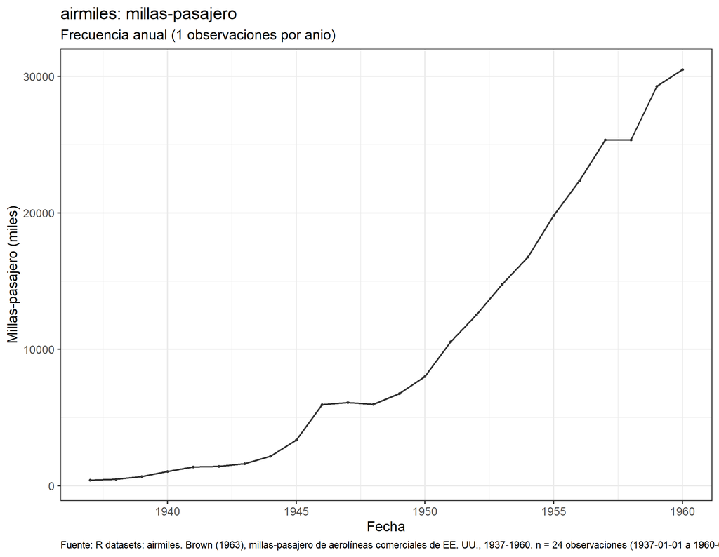

```r
graficar_serie(airm, "airmiles: millas-pasajero")
```

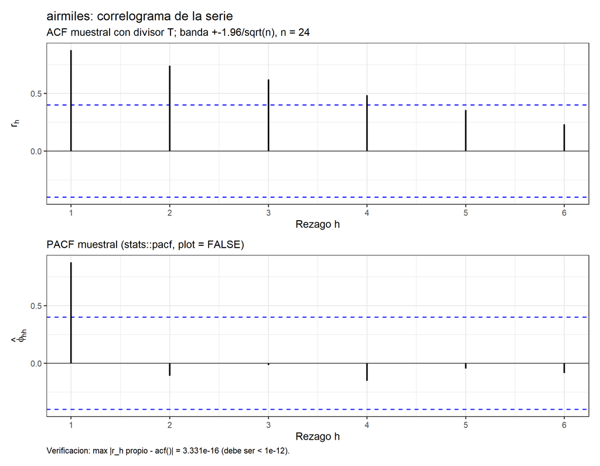

```r
correlograma(airm, titulo = "airmiles: correlograma de la serie")
```

```r
ej6 <- protocolo_ejemplo(airm, "airmiles", function(y) ajustar_tendencia(y, "cuadratica"),
                         "tendencia cuadrática", p = 3, imprimir = FALSE)
par6 <- ej6$ajuste$parametros
knitr::kable(par6$tabla_coeficientes, digits = 5)
```

| coeficiente | estimacion | ee_ordinario | t_ordinario | p_ordinario | ee_hac | t_hac | p_hac |
| --- | --- | --- | --- | --- | --- | --- | --- |
| b0 | 1420.12456 | 554.89763 | 2.55926 | 0.02032 | 517.16241 | 2.74599 | 0.01378 |
| b1 | -473.93042 | 121.69765 | -3.89433 | 0.00117 | 149.35683 | -3.17314 | 0.00556 |
| b2 | 74.32923 | 5.62909 | 13.20450 | 0.00000 | 6.87577 | 10.81031 | 0.00000 |

```r
for (j in seq_len(nrow(par6$tabla_coeficientes))) {
  tc <- par6$tabla_coeficientes[j, ]
  invisible(reportar_prueba(t_coeficiente(tc$estimacion, tc$ee_hac, par6$gl, tc$coeficiente)))
}
```

```
--- t sobre b0 (EE robusto HAC) ---
1. H0: b0 = 0
   H1: b0 != 0
2. Estadistico: t = b0_hat / EE_HAC(b0_hat) ~ t_{T-k}  (gl = 17)
3. Region de rechazo al 5 %: se rechaza H0 si |t| > t_{0.975, 17} = 2.1098
4. Valor observado = 2.745993 ; valor p = 0.01378
5. Decision: se rechaza H0 al 5 %
6. Lectura: Se rechaza H0: el coeficiente b0 es significativamente distinto de cero (con error estandar robusto HAC).

--- t sobre b1 (EE robusto HAC) ---
1. H0: b1 = 0
   H1: b1 != 0
2. Estadistico: t = b1_hat / EE_HAC(b1_hat) ~ t_{T-k}  (gl = 17)
3. Region de rechazo al 5 %: se rechaza H0 si |t| > t_{0.975, 17} = 2.1098
4. Valor observado = -3.173142 ; valor p = 0.00556
5. Decision: se rechaza H0 al 5 %
6. Lectura: Se rechaza H0: el coeficiente b1 es significativamente distinto de cero (con error estandar robusto HAC).

--- t sobre b2 (EE robusto HAC) ---
1. H0: b2 = 0
   H1: b2 != 0
2. Estadistico: t = b2_hat / EE_HAC(b2_hat) ~ t_{T-k}  (gl = 17)
3. Region de rechazo al 5 %: se rechaza H0 si |t| > t_{0.975, 17} = 2.1098
4. Valor observado = 10.810311 ; valor p = 4.884e-09
5. Decision: se rechaza H0 al 5 %
6. Lectura: Se rechaza H0: el coeficiente b2 es significativamente distinto de cero (con error estandar robusto HAC).
```

```r
knitr::kable(dplyr::bind_rows(
  dplyr::mutate(ej6$medidas_dentro, tramo = "estimación"),
  dplyr::mutate(ej6$medidas_fuera,  tramo = "validación"),
  dplyr::mutate(ej6$medidas_referente, tramo = "ingenuo")), digits = 3)
```

| n | MSE | RMSE | MAD | MAPE | MASE | tramo |
| --- | --- | --- | --- | --- | --- | --- |
| 20 | 472846.5 | 687.638 | 518.454 | 20.565 | 0.444 | estimación |
| 4 | 2416497.7 | 1554.509 | 1408.887 | 5.092 | 1.205 | validación |
| 4 | 32979149.5 | 5742.748 | 5254.500 | 18.457 | 4.496 | ingenuo |

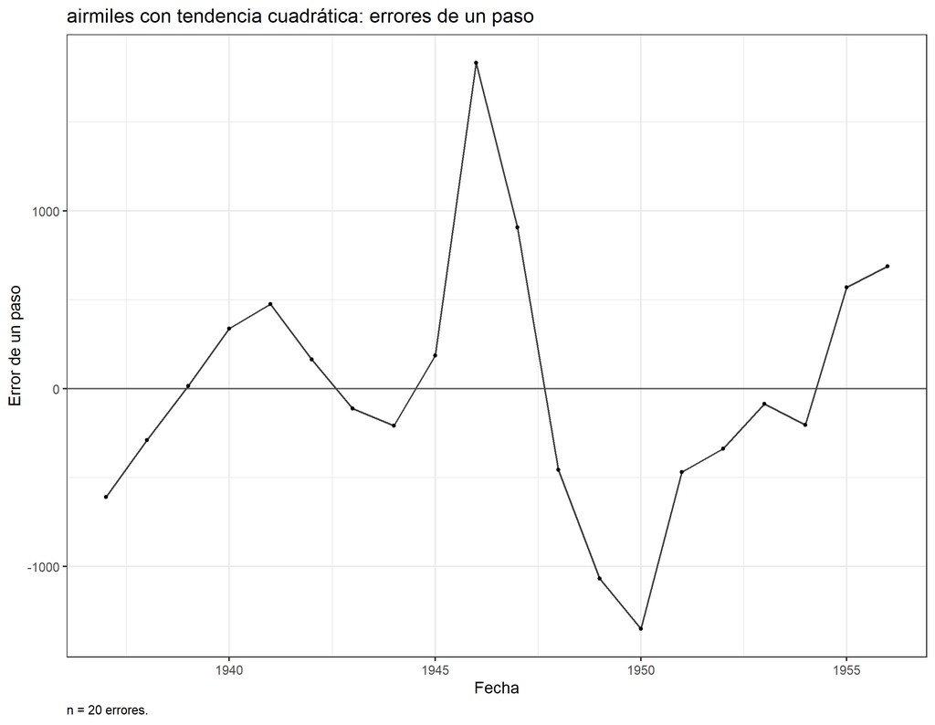

```r
ej6$validacion$grafico_errores
```

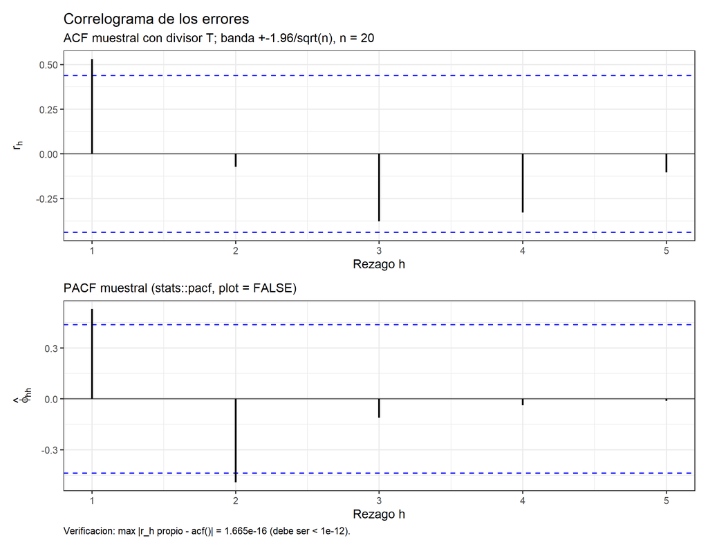

```r
ej6$validacion$correlograma
```

```r
reportar_validacion(ej6)
```

```
=== Prueba sobre la serie airmiles ===
--- Ljung-Box ---
1. H0: rho_1 = ... = rho_m = 0 (los errores/observaciones no estan autocorrelacionados)
   H1: algun rho_h distinto de cero para h = 1,...,m
2. Estadistico: Q_m = T(T+2) sum_{h=1}^{m} r_h^2/(T-h) ~ chi^2_{m-p}  (gl = 6)
3. Region de rechazo al 5 %: se rechaza H0 si Q_m > chi^2_{0.95, 6} = 12.5916
4. Valor observado = 61.306731 ; valor p = 2.441e-11
5. Decision: se rechaza H0 al 5 %
6. Lectura: Se rechaza H0: hay autocorrelacion (estructura temporal) en la serie airmiles.

=== Pruebas sobre los errores de un paso: airmiles con tendencia cuadrática ===
--- t de media cero ---
1. H0: mu_e = 0 (el metodo no esta sesgado)
   H1: mu_e != 0 (el metodo esta sesgado)
2. Estadistico: t = ebar / (s_e/sqrt(n)) ~ t_{n-1}  (gl = 19)
3. Region de rechazo al 5 %: se rechaza H0 si |t| > t_{0.975, 19} = 2.0930
4. Valor observado = -0.000000 ; valor p =     1
5. Decision: no se rechaza H0 al 5 %
6. Lectura: No se rechaza H0: no hay evidencia de sesgo sistematico en los errores de un paso de airmiles con tendencia cuadrática.

--- Ljung-Box ---
1. H0: rho_1 = ... = rho_m = 0 (los errores/observaciones no estan autocorrelacionados)
   H1: algun rho_h distinto de cero para h = 1,...,m
2. Estadistico: Q_m = T(T+2) sum_{h=1}^{m} r_h^2/(T-h) ~ chi^2_{m-p}  (gl = 2)
3. Region de rechazo al 5 %: se rechaza H0 si Q_m > chi^2_{0.95, 2} = 5.9915
4. Valor observado = 13.632938 ; valor p = 0.001096
5. Decision: se rechaza H0 al 5 %
6. Lectura: Se rechaza H0: hay autocorrelacion (estructura temporal) en los errores de un paso de airmiles con tendencia cuadrática.

--- Jarque-Bera ---
1. H0: los errores provienen de una distribucion normal (A = 0 y K = 3)
   H1: los errores no son normales (A != 0 o K != 3)
2. Estadistico: JB = (N/6)(A^2 + (K-3)^2/4) ~ chi^2_2  (gl = 2)
3. Region de rechazo al 5 %: se rechaza H0 si JB > chi^2_{0.95,2} = 5.9915
4. Valor observado = 1.535724 ; valor p = 0.464
5. Decision: no se rechaza H0 al 5 %
6. Lectura: No se rechaza H0: la distribucion de los errores de un paso de airmiles con tendencia cuadrática es compatible con la normal.

--- Durbin-Watson ---
1. H0: rho = 0 (errores no autocorrelacionados de orden 1)
   H1: rho > 0 (autocorrelacion positiva de primer orden)
2. Estadistico: d = sum_t (e_t - e_{t-1})^2 / sum_t e_t^2, con d aprox 2(1 - rho)
3. Region de rechazo al 5 %: se rechaza H0 si d < dL; no se concluye si dL <= d <= dU; no se rechaza si d > dU (cotas de la tabla para T y k regresores)
4. Valor observado = 0.848854 ; valor p = no disponible (ver cotas)
5. Decision: la decision se toma con las cotas dL y dU de la tabla (ver informe)
6. Lectura: d = 0.849, por debajo de 2: sugiere autocorrelacion positiva de primer orden en los errores de un paso de airmiles con tendencia cuadrática; la decision formal se toma con las cotas dL y dU de la tabla.
```

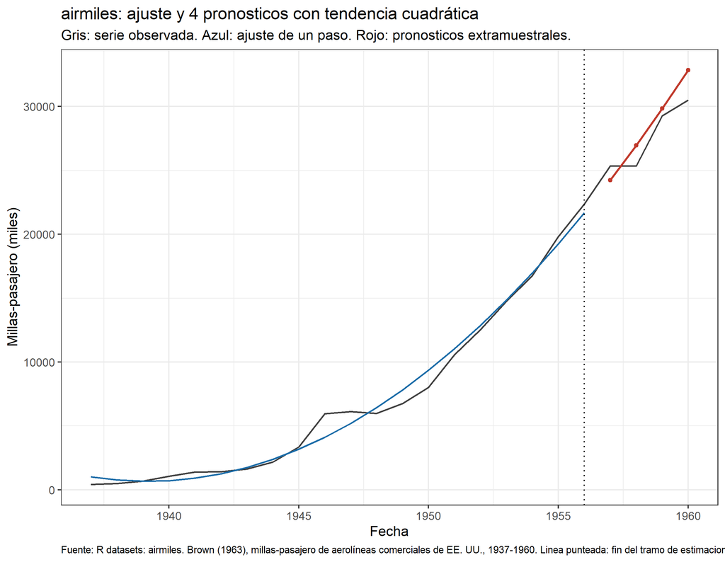

```r
ej6$grafico_final
```

Con 20 errores, la prueba de Jarque–Bera es asintótica y su decisión se reporta con esa advertencia.

**Conclusión.** La tendencia cuadrática, sobre apenas 20 años de estimación, alcanza un MASE de validación de 1.205, casi cuatro veces mejor que el ingenuo (4.496). Los tres coeficientes son significativos con error estándar HAC (t = 2.75, -3.17 y 10.81), y el coeficiente cuadrático positivo y significativo confirma un crecimiento acelerado. Ljung–Box rechaza ($p=$ 0.0011), pero con solo 20 errores y 5 rezagos cualquier estructura residual pesa mucho en la prueba; además, con 20 errores Jarque–Bera está en el límite de su aproximación asintótica, así que su no rechazo ($p=$ 0.464) se lee con esa reserva.

**Recomendación.** Útil para anticipar el crecimiento de millas-pasajero de aerolíneas en el corto plazo (los 4 años de horizonte evaluados), dado el bajo MASE frente al ingenuo. El límite declarado es el tamaño de muestra: con apenas 20 observaciones las pruebas de validación tienen poco poder, y una tendencia cuadrática extrapolada diverge rápido — cualquier pronóstico más allá de unos pocos años debe tomarse con mucha cautela.